# RPMI_PR_20200728

Liz Hughes

13/01/2022

# Plate reader assay#2.

##Test WT H99 and GAt 201 deletion mutants 003(Madhani) and 004(Bahn)in RPMI only. ##7 Bioreps, 3 Techreps each. (NB only 2 Techreps for Biorep 7) ##Grow 5ml culture from colony (1 colony = 1 Biorep)in YPD, 30C, 250 rpm ON. ##Seed at )D 600nm = 0.2 , 200 ul per well. ##Run for 3 days.

```r
library("reshape2")
library(dplyr)
```

```r
library(ggplot2)
library(tidyverse)
library(markdown)
library(cowplot)
```

# Read in transposed data as csv file

```r
rawdata <- read.csv("../PR_Data_Gat201/20200728_EH_PR2_RPMI_WT_Gat201TRSP.csv")

view(rawdata)
```

# Change time in seconds to time in hours

```r
 rawdata_hrs<-mutate(rawdata, Time = Time/3600)
```

# Tidy the data using the melt function from reshape2

```r
reshaped <- melt(rawdata_hrs, id=c("Time", "Temp"),
                              variable.name="Well",
                              value.name="OD595")

summary(reshaped)
```

```
##       Time            Temp            Well           OD595
##  Min.   : 0.00   Min.   :36.50   A1     :  435   Min.   :0.1004
##  1st Qu.:18.54   1st Qu.:37.00   A2     :  435   1st Qu.:0.1501
##  Median :37.25   Median :37.10   A3     :  435   Median :0.1584
##  Mean   :37.25   Mean   :37.11   A4     :  435   Mean   :0.1706
##  3rd Qu.:55.96   3rd Qu.:37.20   A5     :  435   3rd Qu.:0.1971
##  Max.   :74.50   Max.   :37.50   A6     :  435   Max.   :0.2407
##                                  (Other):39150
```

# Read in the Plate map data from csv file

```r
platemap <- read.csv("../PR_Data_Gat201/20200728-PR2_SetupCSV.csv")
head(platemap, n=10)
```

```
##    Well Strain Biorep Techrep Medium
## 1    A1            NA      NA   RPMI
## 2    A2            NA      NA   RPMI
## 3    A3            NA      NA   RPMI
## 4    A4            NA      NA   RPMI
## 5    A5            NA      NA   RPMI
## 6    A6            NA      NA   RPMI
## 7    A7            NA      NA   RPMI
## 8    A8            NA      NA   RPMI
## 9    A9            NA      NA   RPMI
## 10  A10            NA      NA   RPMI
```

# Combine the reshaped data with the plate map, pairing them by Well

```r
annotated <- inner_join(reshaped, platemap, by="Well")
```

# How stable are ODs of blank wells, to use for normalisation?

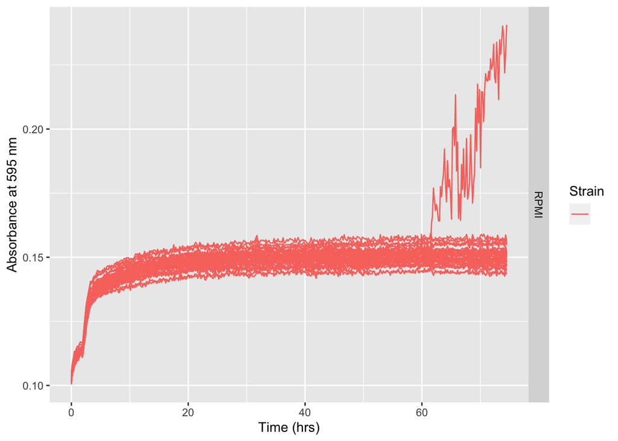

```r
ggplot(data=filter(annotated,Strain==""),
       aes(x=Time, y=OD595, color=Strain, group = Well)) +
       geom_line() +
       facet_grid(Medium ~ .) +
       labs(x="Time (hrs)", y="Absorbance at 595 nm")
```

These are very stable, except H2. Remove from normalisation.

## Calculate median OD for blank wells for each growth medium

Remove well H2

```r
blank_OD_summary <- annotated %>%
  filter(Strain=="") %>%
  filter(Well != "H2") %>%
  # filter out columns 1 and 12 as well?
  group_by(Medium) %>%
  summarise(OD_median=median(OD595),
            OD_mean=mean(OD595),
            OD_max=max(OD595),
            OD_min=min(OD595))
print(blank_OD_summary)
```

```
## # A tibble: 1 × 5
##   Medium OD_median OD_mean OD_max OD_min
##   <chr>      <dbl>   <dbl>  <dbl>  <dbl>
## 1 RPMI       0.149   0.147  0.159  0.100
```

# Subtract blank OD to make corrected OD and Plot OD_corrected v Time (hrs)

```r
normalisedOD <- annotated %>%
  left_join(blank_OD_summary, by="Medium") %>%
  mutate(OD_corrected = OD595 - OD_median)
```

## Plot OD all

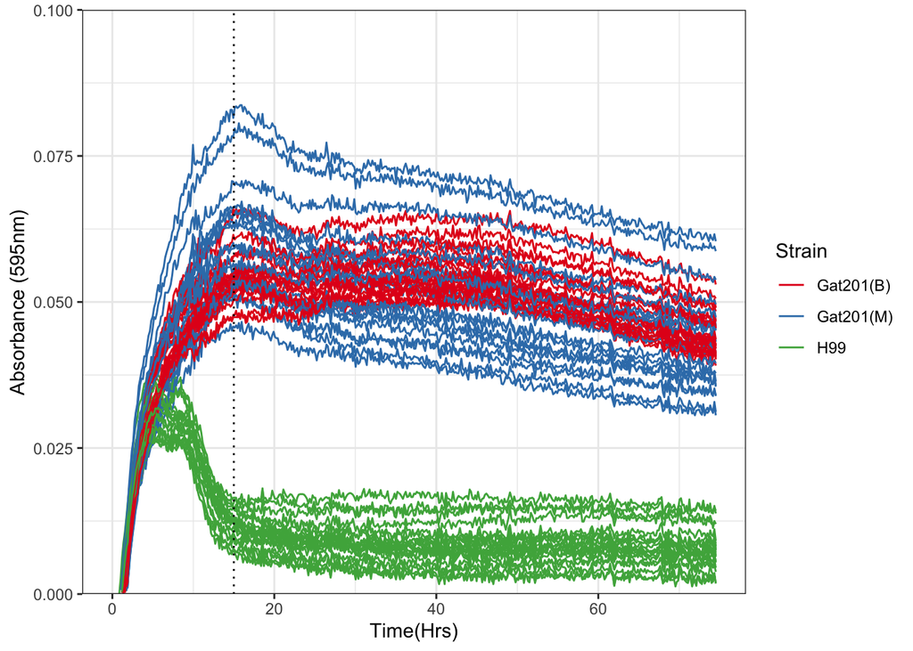

```r
ggplot(data=normalisedOD %>%
                      filter(Strain != ""),
                      aes(x=Time, y=OD_corrected, color=Strain, group = Well)) +
       geom_line() +
       scale_y_continuous(limits=c(0,0.1),expand=c(0,0))+
       geom_vline(aes(xintercept=15), linetype="dotted", colour="black") +

       labs(x = "Time(Hrs)",
            y = "Absorbance (595nm)") +
       theme(text = element_text(size = 20))+
       theme_bw()+
       scale_color_brewer(palette="Set1")
```

## Plot OD all stat_summary(geom -“line”)

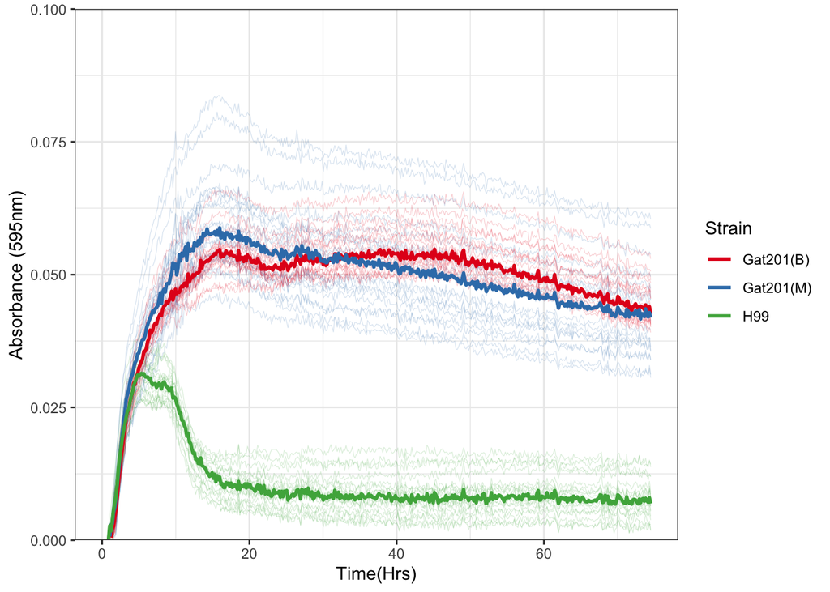

```r
ggplot(data=normalisedOD %>%
                      filter(Strain != ""),
                      aes(x=Time, y=OD_corrected, color=Strain)) +
       geom_line(aes(group = Well), size = 0.2, alpha = 0.2) +
       stat_summary(fun = "median", geom = "line", size = 1) +
       scale_y_continuous(limits=c(0,0.1),expand=c(0,0)) +
       labs(x = "Time(Hrs)",
            y = "Absorbance (595nm)") +
       theme(text = element_text(size = 20)) +
       theme_bw() +
       scale_color_brewer(palette="Set1")
```

Notes from EW: - set `size = 1` for `stat_summary` to emphasize the median value - set `size = 0.2, alpha = 0.2` for `geom_line` to make the individual values barely visible, just enough to see the variability. - `aes(group = Well)` only applies to `geom_line` so that we plot individual wells separately

# Calculate the median of the OD_corrected at each Time and for each Strain

```r
OD_summary <- normalisedOD %>%
  filter(Strain!="") %>%
  group_by(Time,Strain) %>%
  summarise(median_OD_corrected=median(OD_corrected))
OD_summarydf <- as.data.frame(OD_summary)
```

# Join ODSummary and normalisedOD by Time and Strain

```r
normalisedODSummary <- normalisedOD %>%
 left_join(OD_summary, by="Time", "Strain")
```

# Plot median_OD_corrected

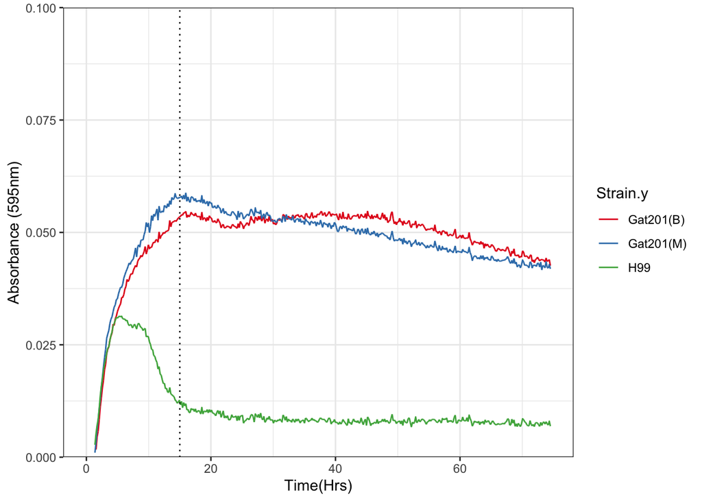

```r
  ggplot(data=normalisedODSummary %>%
        filter(Strain.y != ""),
        aes(x=Time, y=median_OD_corrected, color=Strain.y)) +
        geom_line() +
        scale_y_continuous(limits=c(0,0.1),expand=c(0,0))+
        geom_vline(aes(xintercept=15), linetype="dotted", colour="black") +
        labs(x = "Time(Hrs)",
             y = "Absorbance (595nm)") +
        theme(text = element_text(size = 20))+
        theme_bw()+
        scale_color_brewer(palette="Set1")
```

```r
#  ggplot(data=OD_summarydf %>%
#          aes(x=Time, y=median_OD_corrected, color=Strain)) +
 #         geom_line() +
  #        labs(x = "Time(Hrs)",
   #            y = "Absorbance (595nm)") +
    #      theme(text = element_text(size = 20))+
     #     theme_bw()+
      #    scale_color_brewer(palette="Set1")
```